# Индивидуальный проект, этап 4

Дисциплина - Операционные Системы

Азарцова В. В.

Российский университет дружбы народов, Москва, Россия

Преподаватель Кулябов Д. С.

2 мая 2025

# Информация

## Докладчик

- Азарцова Вероника Валерьевна
- НКАбд-01-24, студ. билет №1132246751
- Российский университет дружбы народов
- 1132246751@pfur.ru
- https://github.com/vvazarcova

## Цели работы

Целью данной лабораторной работы было продолжить работу с личным сайтом на Github pages.

## Задачи

1. Добавить ссылки на сайты.
2. Сделать посты:
   - Сделать пост по прошедшей неделе
   - Добавить пост на тему по выбору: Оформление отчёта; Создание презентаций; Работа с библиографией.

## Теоретическое введение

Hugo Blox Builder — это фреймворк без кода для создания любого типа веб-сайта с использованием виджетов.  
Он позволяет писать контент, используя стандартизированный Markdown вместе с пакетными расширениями для математики и диаграмм, и редактируйте в CMS с открытым исходным кодом или через редактор, такой как онлайн-редактор GitHub, Jupyter Notebook или RStudio.

# Выполнение лабораторной работы

1. Добавляю ссылки на сайты.
- eLibrary : https://elibrary.ru/;
- Google Scholar : https://scholar.google.com/;
- ORCID : https://orcid.org/;
- Mendeley : https://www.mendeley.com/;
- ResearchGate : https://www.researchgate.net/;
- Academia.edu : https://www.academia.edu/;
- arXiv : https://arxiv.org/;
- github : https://github.com/.

## Выполнение лабораторной работы

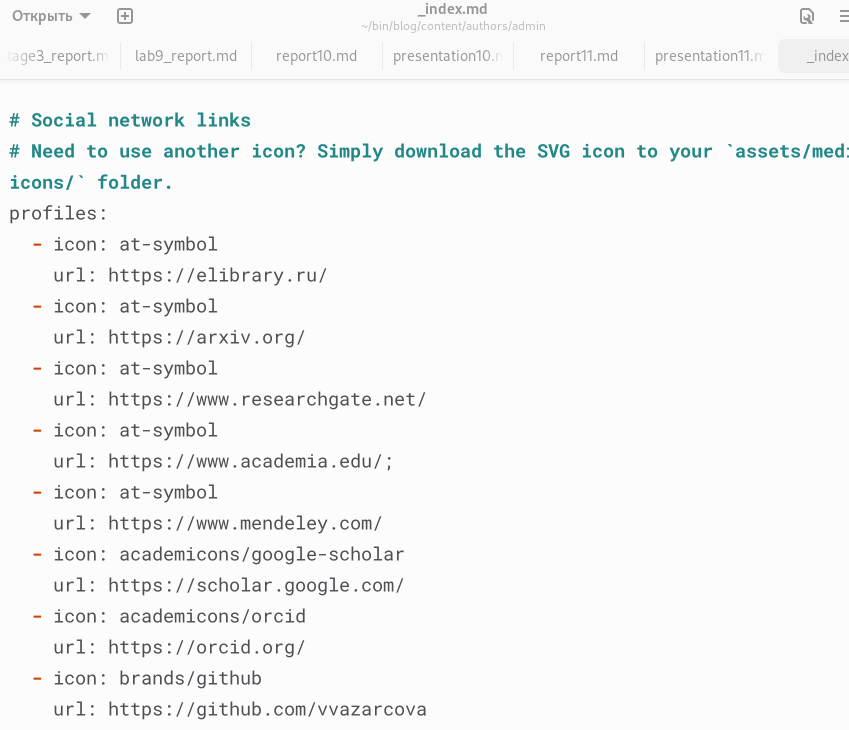

index.md сайта

## Выполнение лабораторной работы

[figure not shown]

Ссылки (ярлыки) на сайте

## Выполнение лабораторной работы

2. Создаю пост о прошедшей неделе.

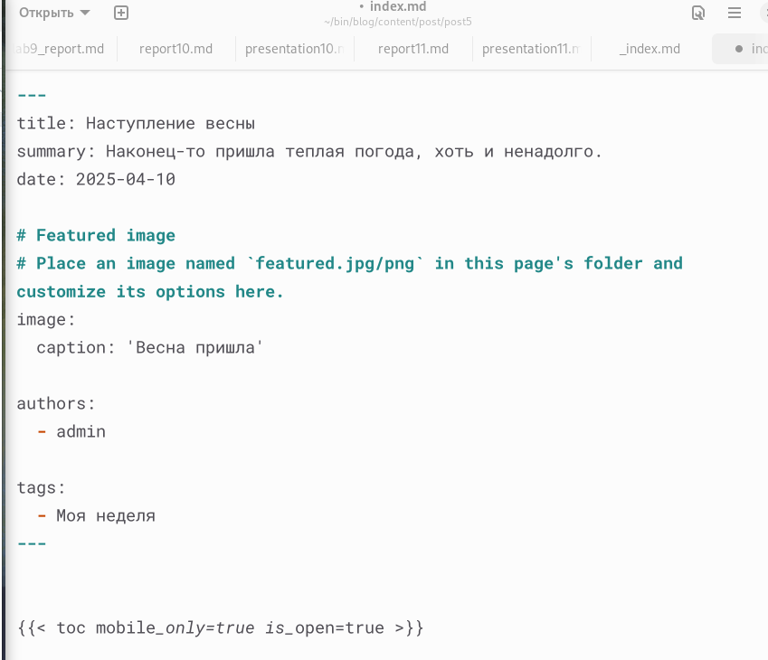

index.md первого поста

## Выполнение лабораторной работы

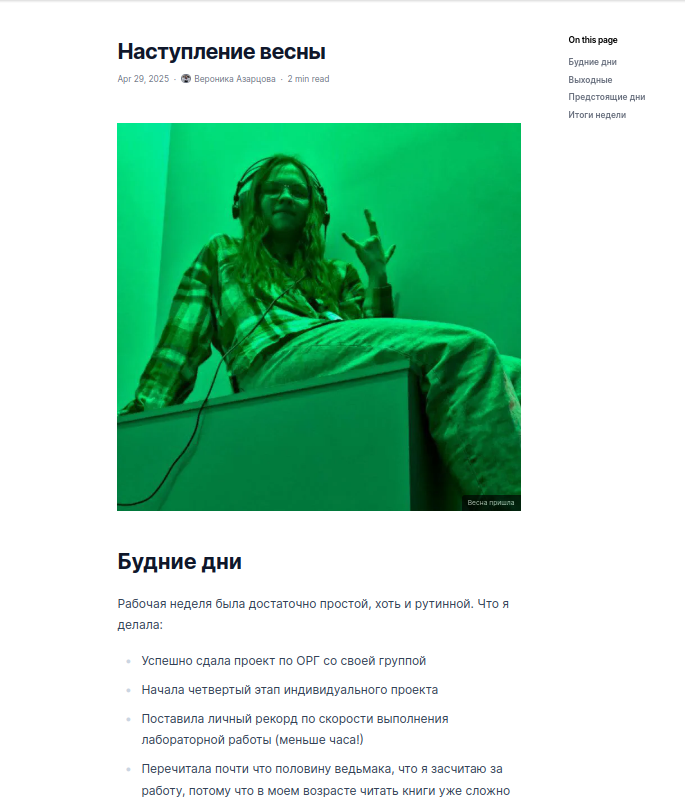

Первый пост на сайте

## Выполнение лабораторной работы

3. Создаю пост о создании презентаций.

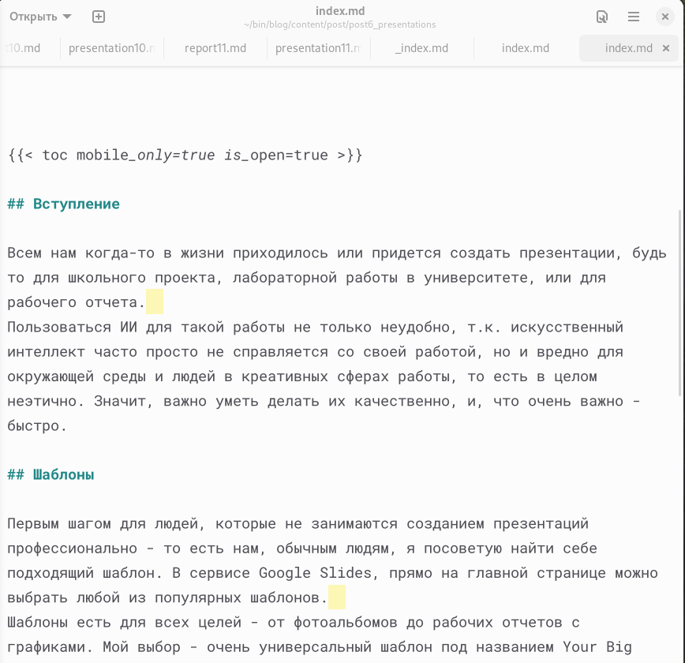

index.md второго поста

## Выполнение лабораторной работы

[figure not shown]

Второй пост на сайте

# Выводы

Мне удалось:

- Дополнить мой сайт ссылками
- Создать два поста: о моей неделе, и о языке создании презентаций, тем самым закрепив мои навыки работы с Hugo.

## Итоговый слайд

Если вам понравилось - посмотрите остальные мои презентации!